# 2021_Lab07_WTA_18_Quillan_Favey

Neuromorphic engineering I

## Lab 7: Winner-Take-All circuit

Team member 1: Quillan Favey

Team member 2: Hooman Javaheri

Team member 3:

Group Number:

Date: 11.15.22

The winner-take-all (WTA) circuit models a neural network consisting of $n$ excitatory cells and one inhibitory cell. When the excitatory cells are active, they excite the inhibitory cell which in turn inhibits all excitatory cells. The inhibitory cell's activity will increase until it silences all excitatory cells but one. If the network loop gain is high enough, this excitatory cell is able to maintain the required inhibitory cell activity by itself. Naturally, the excitatory cell that survives is the one with the largest extrinsic input.

A useful extension of the WTA network is the introduction of positive feedback and lateral coupling through both excitatory and (local) inhibitory nearest neighbor interactions. The positive feedback variant of the classical WTA network shows a hysteretic behavior in the selection/de-selection mechanism, and is therefore denoted the hysteretic winner-take-all (HWTA) network.

In this lab, we will investigate properties of both the classical WTA and HWTA circuits. Circuit schematics of a single cell in the WTA and HWTA networks are shown in Fig. 1. We will first characterize the response properties of the classical WTA circuit and then compare the effect of the various circuit additions to the HWTA circuit. Furthermore we will investigate the effect of the coupling diffusor circuits in the HWTA circuit. These diffusors implement both lateral excitatory and inhibitory coupling between the cells.

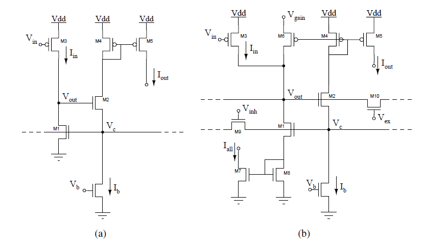

**Figure 1**: (a) Schematic of a single cell of a classical WTA network. (b) Schematic of a single cell of a HWTA network.

# 1 Reading

Study the handouts and read the papers:

**Indiveri, 2001** A current-mode hysteretic winner-take-all network, with excitatory and inhibitory coupling

# 2 Prelab

This prelab will help you develop intuition for the input-output current relationship of the network. We suggest you read the entire Prelab to understand the chain of reasoning before attempting to answer the questions. Assume subthreshold operation unless otherwise stated.

1. To begin, let's consider the 2-node WTA network in Fig. 2. Note that the WTA bias current $I_b$ is identical for both cells (they share the same bias voltage $V_b$). Also note that node $V_c$ is common to both cells. This common node is crucial, as it is through this node that the global competition takes place.

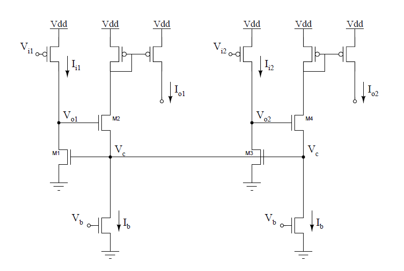

**Figure 2**: Schematic of a 2-node WTA network.

Write down the equations for the (subthreshold) currents flowing through transistors M1 and M3, as a function of their gate, source and drain voltages, separating their *forward* and *reverse* components. Don't take into account, for the time being, the Early effect in the equations.

The equations for the subtreshold currents through transistors M1 and M3 are

$$ \begin{align} I_1 &= I_f - I_r \\ I_1 &= I_0 e^{\kappa V_g/UT}e^{-V_s/UT} - I_0 e^{\kappa V_g/UT}I_0 e^{-V_d/UT} \\ I_1 &= I_0 e^{\kappa V_c/UT}e^{-V_s/UT} - I_0 e^{\kappa V_c/UT}I_0 e^{-V_{o1}/UT} \end{align} $$

As $V_s = gnd$ we get the following: $$ \begin{align} &I_1 = I_0 e^{\kappa V_c/UT}e^{0} - I_0 e^{\kappa V_c/UT}I_0 e^{-V_{o1}/UT} \\ &I_1 = I_0 e^{\kappa V_c/UT} - I_0 e^{\kappa V_c/UT}I_0 e^{-V_{o1}/UT} \\ &I_1 = I_0 e^{\kappa V_c/UT} (1 - e^{-V_{o1}/UT}) \\ \end{align} $$ and if the transistor is in saturation: $$ \begin{align} &I_1 = I_0 e^{\kappa V_c/UT}e^{0} - I_0 e^{\kappa V_c/UT}I_0 e^{-V_{o1}/UT} \\ &I_1 = I_0 e^{\kappa V_c/UT} - I_0 e^{\kappa V_c/UT}I_0 e^{-V_{o1}/UT} \\ &I_1 = I_f = I_0 e^{\kappa V_c/UT} \\ \end{align} $$

The same reasoning is done for M3: $$ \begin{align} &I_3 = I_f - I_r \\ &I_3 = I_0 e^{\kappa V_g/UT}e^{-V_s/UT} - I_0 e^{\kappa V_g/UT}I_0 e^{-V_d/UT} \\ &I_3 = I_0 e^{\kappa V_c/UT}e^{-V_s/UT} - I_0 e^{\kappa V_c/UT}I_0 e^{-V_{o2}/UT} \\ &I_3 = I_0 e^{\kappa V_c/UT}(1 - e^{-V_{o2}/UT}) \end{align} $$ and if the transistor is in saturation: $$ \begin{align} &I_1 = I_0 e^{\kappa V_c/UT}e^{0} - I_0 e^{\kappa V_c/UT}I_0 e^{-V_{o1}/UT} \\ &I_1 = I_0 e^{\kappa V_c/UT} - I_0 e^{\kappa V_c/UT}I_0 e^{-V_{o1}/UT} \\ &I_3 = I_f = I_0 e^{\kappa V_c/UT} \\ \end{align} $$

Given that the gate voltages of M1 and M3 are the same, under the different conditions given below, what is $V_c$, what happens to $V_{o1}$ and $V_{o2}$, $I_{o1}$ and $I_{o2}$ :

- $I_{i1} = I_{i2} = I_{in}$.

> The current flowing through M1 and M3 is the same ($I_{o1} = I_{o2}$) (as their gates are tied to $V_c$ ) and $V_{o1}=V_{o2}=V_c + V_b$ (the drain voltages must be equal). $V_c$ (determined by $V_{o1} and V_{o2}$) is the source voltage for M2 and M4.

> Also due to KCL, at the $V_c$ node we have,

$I_{out1} = I_{out2} = I_b/2$

- $I_{i1} \gg I_{i2}$

> As the gate voltages for M1 and M3 are the same, the forward current in both transistors is the same. $V_{o1}$ and $V_{o2}$ have to adjust (to $\approx log(I_b)$), but as $I_{i1} \gg I_{i2}$, $V_{o2} < 4Ut$ (to "compensate" for a large $V_c$), M4 will shut off.

> Also,

$V_c = \frac{U_T}{\kappa}ln(I_{i1}/I_0)$

$I_{o1}=I_b$

$I_{o2}= 0$

$V_{O1}=V_c + V_b$

$V_{o2} \approx 0$

Generalize your results to an $n$-input WTA circuit.

> for $I_{i1}=I_{i2}=...=I_{in}$, we have: $$ \begin{align} &I_{out1}=I_{out2}=...=I_{outn}=I_b/n \\ &V_{o1}=V_{o2}=...=V_{on}=V_c + V_b \\ &I_{o1}=I_{o2}=...=I_{on} \end{align} $$

> for $I_{i1}>>I_{i2}>>...>>I_{in}$, (all sufficiently different inputs) we have: $$ \begin{align} &I_{out1}=I_b \\ &I_{out2}=...=I_{outn}=0 \\ &V_{o1}=V_c + V_b \\ &V_{o2}\approx ... \approx V_{on}\approx 0 \end{align} $$
1. The analysis above applies when the input currents are sufficiently different. To understand what happens when the inputs are very similar, we have to take into account the Early effect on devices M1 and M3. Let's do a small-signal analysis.

Proceed as follows:

- To help you in your reasoning, draw a transistor's subthreshold $I_{ds}$ vs. $V_{ds}$ curve.

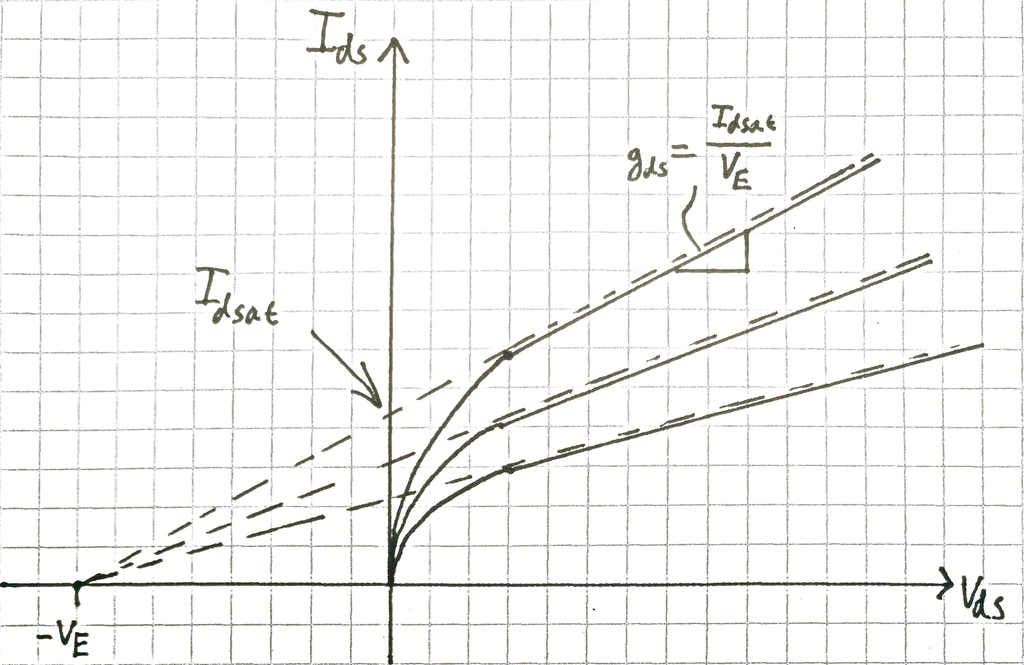

- Assume that $V_c$ does not change. Given that the drain conductance of M1 and M3 is $g_{\rm d}$, figure out how much $V_{o1}$ and $V_{o2}$ must change to accomodate the change in current.

> By increasing the input current $I_{i1}$ by $\delta I$, $V_{o1}$ (M1's drain voltage) must increase by $\delta V$. We know the early effect of a transistor operating in saturation realates to the current via the following relation: $$ \begin{align} I_{ds}=I_{i1}=I_{sat}(1+\frac{V_{ds}}{V_e}) \end{align} $$

> applying this relation to M3, we get by how much $V_{o1}$ must increase ($\delta I = \Delta I_{in}$):

$$ \begin{align} \delta V = \frac{\delta I}{I_{sat}}V_e=\frac{\delta I}{g_{ds}} \end{align} $$

> replacing $\delta I $ by $\frac{1}{2} \Delta I_{in}$, we get :

$$ \begin{align} \delta V =\frac{\Delta I_{in}}{2g_{ds}} \end{align} $$

> $V_{o2}$ will *decrease* by $\delta V$ to accomodate the change in current
- Given these changes, use the small-signal transconductance $g_{\rm m}$ of M2 and M4 to figure out how much the output currents will change? Assuming that $I_{i1} = I_{i2} = I_u$ and $I_{b}$ are in the same order of currents (e.g. $ I_{u} / I_{b} \approx$ 1 ), early voltage of M1 and M3 is $V_e$ = 25V, $U_T$ = 25mV, $\kappa$ = 1. (This is to have an intuitive understanding that how sensitive is the change of output currents conrresponding to the change of input current.)

$g_m = \frac{\kappa I}{U_T} =\frac{\delta I}{\delta V_{gs}}$

> with the previous equation we get:

$$ \begin{align} \delta I_{out} =\frac{\Delta I_{in}g_m}{2g_{ds}} \end{align} $$

> Also, $I_{out 1}$ will increase by an amount proportional to $e^{\delta V}$
- Express the drain conductance and transconductance in terms of $I_u$ and $I_b$ and obtain a relationship between the normalized input and output signals, $\Delta{I_{in}}/I_u$ and $\Delta{I_{out}}/I_b$.

$$ \begin{align} \frac{\Delta{I_{out}}}{I_b} = \frac{\kappa I_b V_e}{2U_T} \frac{\Delta I_{in}}{I_u} \end{align} $$

1. The circuit on the CoACH chip has the circuit of Fig. 1 (b), which has four differences from Fig. 1 (a). In order to conduct the experiment, you need to answer the following questions:
- M6

What function does it implement?

> M5 ? Local excitatory feedback and the hysteresis behaviour

What should $V_{gain}$ be in order to disable this function?

> Vgain<Vdd

What should $V_{gain}$ be in order to enable this function, and what is the effect?

> Vgain=Vdd (if Vgain is the source of M5), the effect is a hysteretic behaviour (once a cell is selected as a winner, a current proportional to $I_b$ is sourced back into the input node via the M3-M5 current mirror.)
- M7 and M8

What function does it implement?

> (M6 and M7?) Diode source degeneration

**(Optional)** What other effect does it introduce? (Hint: Discuss the changes in $V_{c}$, $V_o$ and $I_o$ in two cases for a 2-WTA: $I_{i1} = I_{i2}$ and $I_{i1} \gg I_{i2}$)

> It increases the winner's selectivity gain...
- M9

What function does it implement?

> M8 is inhibitory lateral coupling

What should $V_{inh}$ be in order to turn off this function?

> $V_{inh}=0V$, but setting $V_{inh} = V_{dd}$ yields global inhibition and could also be a way to neglect this feature

What should $V_{inh}$ be in order to turn on this function, and what is the effect?

> $V_{inh} = V_{dd}$ for global inhibition

> For $V_{dd}>V_{inh}>0$ inhibition is local and allows to select multiple winner cells
- M10

What function does it implement?

> where is M10? M9 is excitatory lateral coupling

What should $V_{ex}$ be in order to turn off this function?

> $V_{ex} = 0V$

What should $V_{ex}$ be in order to turn on this function, and what is the effect?

> $V_{ex}>0$, The effect is that an increase in $V_{ex}$ will increase exponentially the amount of spreading as well as smooth signal inputs

# 3 Setup

## 3.1 Connect the device

```python
# import the necessary libraries
import pyplane
import time
import numpy as np
import matplotlib.pyplot as plt
from scipy import interpolate
```

```python
# create a Plane object and open the communication
if 'p' not in locals():
    p = pyplane.Plane()
    try:
        p.open('/dev/ttyACM0')
    except RuntimeError as e:
        del p
        print(e)
```

```python
p.get_firmware_version()
```

```
(1, 8, 8)
```

```python
# Send a reset signal to the board, check if the LED blinks
p.reset(pyplane.ResetType.Soft)

time.sleep(0.5)
# NOTE: You must send this request events every time you do a reset operetion, otherwise the recieved data is noisy.
# Because the class chip need to do handshake to get the communication correct.
p.request_events(1)
```

```python
# Try to read something, make sure the chip responses
p.read_current(pyplane.AdcChannel.GO0_N)
```

```
1.369628961356284e-07
```

```python
# If any of the above steps fail, delete the object, and restart the kernel

# del p
```

## 3.1 Chip configuration

To measure $I_{out}$, use:

```
p.send_coach_events([pyplane.Coach.generate_aerc_event(
    pyplane.pyplane.Coach.CurrentOutputSelect.SelectLine2,
    pyplane.Coach.VoltageOutputSelect.SelectLine0,
    pyplane.Coach.VoltageInputSelect.SelectLine0,
    pyplane.Coach.SynapseSelect.NoneSelected,0)])
```

To measure $I_{all}$, use:

```
p.send_coach_events([pyplane.Coach.generate_aerc_event(
    pyplane.pyplane.Coach.CurrentOutputSelect.SelectLine3,
    pyplane.Coach.VoltageOutputSelect.SelectLine0,
    pyplane.Coach.VoltageInputSelect.SelectLine0,
    pyplane.Coach.SynapseSelemct.NoneSelected,0)])
```

## 3.2 Bias Generator (BiasGen or BG)

In a simplified form, the output of a branch of the BiasGen will be the gate voltage $V_b$ for the bias current $I_b$, and if the current mirror has a ratio of $w$ and the bias transistor operates in subthreshold-saturation: \begin{equation} I_b = w\frac{BG_{fine}}{256}I_{BG_{master}} \end{equation} Where $I_{BG_{master}}$ is the `BiasGenMasterCurrent` $\in \left\{ 60~\rm{pA}, 460~\rm{pA}, 3.8~\rm{nA}, 30~\rm{nA}, 240~\rm{nA} \right\}$, $BG_{fine}$ is the integer fine value $\in [0, 256)$

To set a bias, use the function similar to the following:

```
p.send_coach_events([pyplane.Coach.generate_biasgen_event(\
    pyplane.Coach.BiasAddress.BIAS_NAME, \
    pyplane.Coach.BiasType.BIAS_TYPE, \
    pyplane.Coach.BiasGenMasterCurrent.MASTER_CURRENT, FINE_VALUE)])
```

**You may have noticed that there are some biases that are not used to directly generate a current, but rather what matters is the voltage, e.g. $V_{gain}$, $V_{ex}$ and $V_{inh}$ in our HWTA circuit. Even though they may have a `BIAS_NAME` ending with `_N` or `_P` it only indicates that they are connected to the gate of an N- or a P-FET, but the `BIAS_TYPE` parameter can be both `_N` or `_P`. For example, setting a `_N` bias to `BIAS_TYPE = P` in the case of Ib=0 will only make this voltage very close to VDD, which *is* sometimes the designed use case.**

## 3.3 Setup C2F and voltage output buffer

```python
# # setup C2F

p.send_coach_events([pyplane.Coach.generate_biasgen_event(\
    pyplane.Coach.BiasAddress.C2F_HYS_P, \
    pyplane.Coach.BiasType.P, \
    pyplane.Coach.BiasGenMasterCurrent.I60pA, 100)])

time.sleep(0.2)
p.send_coach_events([pyplane.Coach.generate_biasgen_event(\
    pyplane.Coach.BiasAddress.C2F_BIAS_P, \
    pyplane.Coach.BiasType.P, \
    pyplane.Coach.BiasGenMasterCurrent.I240nA, 255)])

time.sleep(0.2)
p.send_coach_events([pyplane.Coach.generate_biasgen_event(\
    pyplane.Coach.BiasAddress.C2F_PWLK_P, \
    pyplane.Coach.BiasType.P, \
    pyplane.Coach.BiasGenMasterCurrent.I240nA, 255)])

time.sleep(0.2)
p.send_coach_events([pyplane.Coach.generate_biasgen_event(\
    pyplane.Coach.BiasAddress.C2F_REF_L, \
    pyplane.Coach.BiasType.N, \
    pyplane.Coach.BiasGenMasterCurrent.I30nA, 255)])

time.sleep(0.2)
p.send_coach_events([pyplane.Coach.generate_biasgen_event(\
    pyplane.Coach.BiasAddress.C2F_REF_H, \
    pyplane.Coach.BiasType.P, \
    pyplane.Coach.BiasGenMasterCurrent.I30nA, 255)])

time.sleep(0.2)
# setup output rail-to-rail buffer
p.send_coach_events([pyplane.Coach.generate_biasgen_event(\
    pyplane.Coach.BiasAddress.RR_BIAS_P, \
    pyplane.Coach.BiasType.P, \
    pyplane.Coach.BiasGenMasterCurrent.I240nA, 255)])
```

# 3.4 Schematic and pin map

In this Lab you will work with the WTA circuits on the CoACH chip.

The winner-take-all circuit comprises 16 cells, with the first cell connected to the last cell by "wrap-around lines", VO & VC. There are four circuit biases parameters, shared by all cells: $V_b$, $V_{ex}$, $V_{inh}$ and $V_{gain}$.

As this circuit is known to be sensitive to mismatch, dummies were used extensively: both within the cells to ensure cell devices are surrounded by same geometries, as well as by placing dummy cells on either side of the array to mitigate corner effects on Cell 1 and Cell 16. (No need to know the details)

Schematic of each cell of the WTA circuit is shown below (It should be WTA instead of WTC). Hysteresis is enabled (`VHEN_VSI = 0`) by default, but you can easily set $V_{gain}$ to disable it.

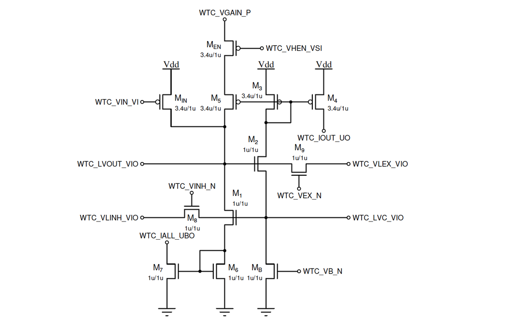

**For cell $x$ $\left(0 \le x < 16\right)$:**

- `WTC_VIN_VI[x]` = $V_{in,x}$ = AINx
- `WTC_LVOUT_VIO[x]` = $V_{out,x}$ = ADC[15-x]
- `WTC_IOUT_UO[x]` = $I_{out,x}$ = C2F[x] (CurrentOutputSelect = SelectLine2)
- `WTC_IALL_UBO[x]` = $I_{all,x}$ = C2F[x] (CurrentOutputSelect = SelectLine3)

# 4 Calibration

## 4.1 Calibration of C2F channels for $I_{out}$

In order to calibrate each C2F channel more accurately, we construct a case when only the calibrated cell wins, so that all 16 $I_b$ flow through the winning channel.

### 4.1.1 Chip configuration

```python
# Select Line2 to read Iout
p.send_coach_events([pyplane.Coach.generate_aerc_event(
    pyplane.pyplane.Coach.CurrentOutputSelect.SelectLine2,
    pyplane.Coach.VoltageOutputSelect.SelectLine0,
    pyplane.Coach.VoltageInputSelect.SelectLine0,
    pyplane.Coach.SynapseSelect.NoneSelected,0)])
```

### 4.1.2 Set fixed voltages

- What value should bias `WTA_VGAIN_P` take?

```python
p.send_coach_events([pyplane.Coach.generate_biasgen_event(\
pyplane.Coach.BiasAddress.WTA_VGAIN_P,\
pyplane.Coach.BiasType.P, \
pyplane.Coach.BiasGenMasterCurrent.I30nA, 255)])  # ??? = 0 ~ 255
```

Hint: The output feedback has been turned off by setting $V_{gain}\ll V_{dd}$.

- What value should bias `WTA_VEX_N` take?

```python
p.send_coach_events([pyplane.Coach.generate_biasgen_event(\
pyplane.Coach.BiasAddress.WTA_VEX_N,\
pyplane.Coach.BiasType.N, \
pyplane.Coach.BiasGenMasterCurrent.I30nA, 0)])  # ??? = 0 ~ 255
```

The excitatory lateral coupling has been turned off by setting $V_{ex}= 0 \text{V}$.

- What value should bias `WTA_VINH_N` take?

```python
p.send_coach_events([pyplane.Coach.generate_biasgen_event(\
pyplane.Coach.BiasAddress.WTA_VINH_N,\
pyplane.Coach.BiasType.P, \
pyplane.Coach.BiasGenMasterCurrent.I30nA, 0)])  # ??? = 0 ~ 255
```

The inhibitory lateral coupling has been turned on by setting $V_{inh}= 1.8V $.

- What value should the $V_{in}$ of the non-winning cells take?

```python
V_lose = 1.8  # ??? V
for i in range(16):
    p.set_voltage(eval('pyplane.DacChannel.AIN' + str(i)), V_lose)
    time.sleep(0.2)
```

(the input transistors are pFETs)

$V_{in,lose} = 1.8 \text{V}$.

- What value should the $V_{in}$ of the winning cell take?

$V_{in,win} = 0 \text{V}$.

Why?

> Because it's a pFET and if we want it to be 'on' we have to set it's gate voltage to 0V.

### 4.1.3 Data aquisition

- For each cell, sweep the total bias current ($16 I_b$ from 0 to 10 nA). Because we don't need too high precision, and it takes 16x the time, only 6 points (including 0) per channel is enough.

```python
N_samples = 6
Ib = np.linspace(0, 10e-9, N_samples)
fine = np.round((Ib/16/460e-12)/3 * 256).astype(int)  # think about this equation, understand why we calculate as this. Here '3' comes from the ratio of current mirror when copy current from bias generator

c2f = np.zeros([16, N_samples])

for i in range(16):
    VC_win = eval('pyplane.DacChannel.AIN' + str(i))
    p.set_voltage(VC_win, V_win)
    for j in range(N_samples):
        p.send_coach_events([pyplane.Coach.generate_biasgen_event(
            pyplane.Coach.BiasAddress.WTA_VB_N, pyplane.Coach.BiasType.N,
            pyplane.Coach.BiasGenMasterCurrent.I460pA, fine[j])])
        time.sleep(0.2)

        # read c2f values
        c2f_temp = p.read_c2f_output(0.1)
        c2f[i][j] = c2f_temp[i]
#         print(c2f_temp)   # debug
        print(c2f)  # debug

    p.set_voltage(VC_win, V_lose)
```

[output not shown]

[output cut: 1481 more lines]

```
 [5.000e+00 9.850e+02 1.857e+03 2.747e+03 3.613e+03 4.363e+03]
 [4.000e+00 6.930e+02 1.323e+03 1.973e+03 2.618e+03 3.203e+03]
 [4.000e+00 7.950e+02 1.513e+03 2.243e+03 2.979e+03 3.648e+03]
 [5.000e+00 9.550e+02 1.820e+03 2.710e+03 3.622e+03 4.380e+03]
 [4.000e+00 6.820e+02 1.297e+03 1.929e+03 2.565e+03 3.131e+03]
 [4.000e+00 8.360e+02 1.589e+03 2.362e+03 3.143e+03 3.814e+03]
 [4.000e+00 8.710e+02 1.651e+03 2.446e+03 3.239e+03 3.907e+03]
 [5.000e+00 1.028e+03 1.932e+03 2.854e+03 3.781e+03 4.541e+03]
 [7.000e+00 8.530e+02 1.608e+03 2.384e+03 3.180e+03 3.868e+03]
 [5.000e+00 9.590e+02 1.817e+03 2.698e+03 3.559e+03 4.317e+03]
 [4.000e+00 6.070e+02 1.151e+03 1.716e+03 2.276e+03 2.782e+03]
 [5.000e+00 1.122e+03 2.128e+03 3.153e+03 4.125e+03 4.984e+03]
 [4.000e+00 6.630e+02 1.265e+03 1.890e+03 2.563e+03 3.639e+03]
 [4.000e+00 8.960e+02 1.702e+03 2.521e+03 3.341e+03 4.040e+03]
 [4.000e+00 8.490e+02 1.607e+03 2.385e+03 3.154e+03 3.854e+03]]
```

- Save data

```python
np.savetxt('./data/data_ex_4_1_3.csv', c2f, delimiter=',')
```

- Plot data (Hint: `np.transpose`)

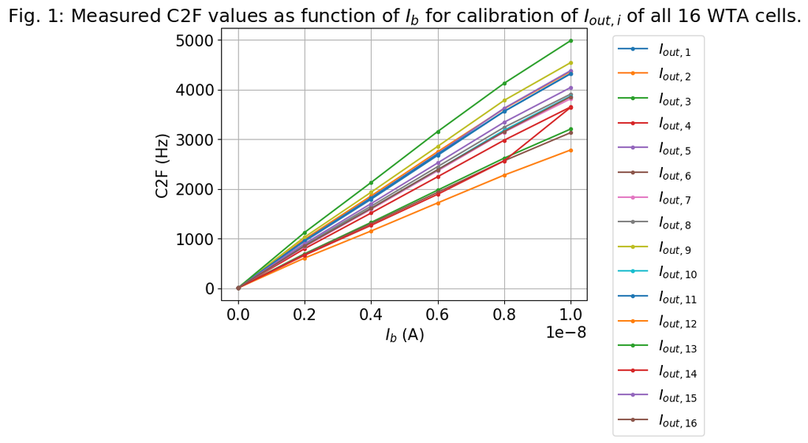

```python
import matplotlib.pyplot as plt
import numpy as np
plt.rcParams.update({'font.size': 15})

N_samples = 6
Ib = np.linspace(0, 10e-9, N_samples)
c2f = np.loadtxt('./data/data_ex_4_1_3.csv',delimiter=',')
plt.plot(Ib,np.transpose(c2f),'.-')

plt.xlabel('$I_b$ (A)')
plt.ylabel('C2F (Hz)')
plt.legend(['${I_{out,1}}$','${I_{out,2}}$','${I_{out,3}}$','${I_{out,4}}$','${I_{out,5}}$','${I_{out,6}}$','${I_{out,7}}$','${I_{out,8}}$','${I_{out,9}}$','${I_{out,10}}$','${I_{out,11}}$','${I_{out,12}}$','${I_{out,13}}$','${I_{out,14}}$','${I_{out,15}}$','${I_{out,16}}$'],prop={'size': 14},bbox_to_anchor=(1.05, 1),loc='upper left')
plt.title('Fig. 1: Measured C2F values as function of $I_b$ for calibration of $I_{out,i}$ of all 16 WTA cells.')
plt.grid()
plt.show()
```

- Fit data

```python
import numpy as np
c2f = np.loadtxt('./data/data_ex_4_1_3.csv',delimiter=',')
N_samples = 6
Ib = np.linspace(0, 10e-9, N_samples)
c2f_ch1 = np.polyfit(c2f[0],Ib,2)
c2f_ch2 = np.polyfit(c2f[1],Ib,2)
c2f_ch3 = np.polyfit(c2f[2],Ib,2)
c2f_ch4 = np.polyfit(c2f[3],Ib,2)
c2f_ch5 = np.polyfit(c2f[4],Ib,2)
c2f_ch6 = np.polyfit(c2f[5],Ib,2)
c2f_ch7 = np.polyfit(c2f[6],Ib,2)
c2f_ch8 = np.polyfit(c2f[7],Ib,2)
c2f_ch9 = np.polyfit(c2f[8],Ib,2)
c2f_ch10 = np.polyfit(c2f[9],Ib,2)
c2f_ch11 = np.polyfit(c2f[10],Ib,2)
c2f_ch12 = np.polyfit(c2f[11],Ib,2)
c2f_ch13 = np.polyfit(c2f[12],Ib,2)
c2f_ch14 = np.polyfit(c2f[13],Ib,2)
c2f_ch15 = np.polyfit(c2f[14],Ib,2)
c2f_ch16 = np.polyfit(c2f[15],Ib,2)

print(c2f_ch1)
print ('The I1(f1) function is :')
print (np.poly1d(c2f_ch1))
```

```
[ 3.94728643e-17  2.13550982e-12 -1.21945695e-11]
The I1(f1) function is :
           2
3.947e-17 x + 2.136e-12 x - 1.219e-11
```

## 4.2 Calibration of input current $I_{in}$ vs input voltage $V_{in}$

The input is given as voltage (`WTC_VIN_VI` = $V_{in}$), so we want to know the exact current $I_{in} (= I_{all})$ first.

### 4.2.1 Chip configuration

```python
# Select Line3 to read Iin (when Iall=Iin)
p.send_coach_events([pyplane.Coach.generate_aerc_event(
    pyplane.pyplane.Coach.CurrentOutputSelect.SelectLine3,
    pyplane.Coach.VoltageOutputSelect.SelectLine0,
    pyplane.Coach.VoltageInputSelect.SelectLine0,
    pyplane.Coach.SynapseSelect.NoneSelected,0)])
```

### 4.2.2 Set fixed voltages

- What value should bias `WTA_VGAIN_P` take?

```python
p.send_coach_events([pyplane.Coach.generate_biasgen_event(\
pyplane.Coach.BiasAddress.WTA_VGAIN_P,\
pyplane.Coach.BiasType.P, \
pyplane.Coach.BiasGenMasterCurrent.I30nA, 255)])
```

- What value should bias `WTA_VEX_N` take?

```python
p.send_coach_events([pyplane.Coach.generate_biasgen_event(\
pyplane.Coach.BiasAddress.WTA_VEX_N,\
pyplane.Coach.BiasType.N, \
pyplane.Coach.BiasGenMasterCurrent.I30nA, 0)])
```

The excitatory lateral coupling has been turned off by setting $V_{ex}=0\text{V}$.

- What value should bias `WTA_VINH_N` take?

```python
p.send_coach_events([pyplane.Coach.generate_biasgen_event(\
pyplane.Coach.BiasAddress.WTA_VINH_N,\
pyplane.Coach.BiasType.P, \
pyplane.Coach.BiasGenMasterCurrent.I30nA, 255)])
```

- What value should bias `WTA_VB_N` take?

```python
p.send_coach_events([pyplane.Coach.generate_biasgen_event(\
pyplane.Coach.BiasAddress.WTA_VB_N,\
pyplane.Coach.BiasType.N, \
pyplane.Coach.BiasGenMasterCurrent.I30nA, 0)])
```

The bias current has been set to $V_b= 0 \text{V}$.

### 4.2.3 Data aquisition

Assume that the c2f calibration in 4.1 is accurate， then if we sweep $V_{in}$ and measure the c2f response (which is connected to $I_{all}$ now, we can obtain the bijection between $V_{in}$ and $I_{in}$.

- What is the model of $I_{in}(V_{in})$ in subthreshold? (PFET)

Assuming that the input transistor is in saturation, the input current in subtreshold can be determined by the equation

$I_{in} = I_0 e^{ (-\kappa V_{in}+V_{dd})/U_T}$.

- Now sweep $V_{in}$ for all 16 channels at the same time to get the missing parameter in the model.

**Important:** Because all 16 channels are monitored by the c2f at the same time, if each channels has 50k events per second (this is the value everyone achieved in the last labs), it will result in almost 1M events per second in total, which is beyond the microcontroller's ability to handle and it will halt (and we have to repower it manually!). So in order to prevent this situation, **please never set any $V_{in}$ below 1.5V!**

```python
N_samples = 25
Vi_set = np.linspace(1.8, 1.5, N_samples)
Vi = np.zeros(N_samples)
c2f = np.zeros([16, N_samples])
for j in range(N_samples):
    for i in range(16):
        p.set_voltage(eval('pyplane.DacChannel.AIN' + str(i)), Vi_set[j])
    Vi[j] = p.get_set_voltage(pyplane.DacChannel.AIN0)
    time.sleep(0.3)
    c2f[:,j] = p.read_c2f_output(0.1) #p.read_all_sampled_c2fs()
    print(c2f)
```

[output not shown]

[output cut: 745 more lines]

```
   16.  22.  29.  39.  54.  74. 109. 150. 208. 289. 404.]
 [  5.   5.   5.   5.   5.   6.   6.   7.   7.   8.  10.  12.  15.  20.
   26.  35.  47.  64.  87. 120. 174. 241. 333. 462. 640.]
 [  3.   3.   3.   3.   3.   4.   4.   4.   5.   6.   7.   9.  12.  16.
   21.  28.  38.  52.  71.  99. 143. 199. 275. 381. 529.]
 [  2.   2.   2.   3.   3.   3.   3.   4.   4.   5.   7.   9.  11.  15.
   20.  27.  38.  51.  70.  98. 143. 200. 278. 388. 541.]
 [  3.   3.   3.   3.   3.   3.   3.   4.   4.   5.   7.   7.   9.  12.
   16.  22.  29.  40.  55.  76. 110. 153. 215. 299. 415.]
 [  2.   2.   2.   3.   3.   3.   3.   3.   3.   4.   5.   6.   7.   9.
   12.  16.  21.  28.  38.  53.  76. 105. 145. 201. 280.]
 [  3.   3.   3.   3.   3.   3.   4.   4.   5.   6.   7.   9.  11.  15.
   20.  27.  37.  50.  69.  96. 140. 194. 272. 377. 526.]
 [  3.   3.   3.   3.   3.   3.   3.   4.   4.   5.   6.   8.  10.  12.
   17.  22.  29.  40.  54.  75. 108. 149. 207. 284. 393.]]
```

- Save data

```python
np.savetxt('./data/Vi_ex_4_2_3.csv', Vi, delimiter=',')
np.savetxt('./data/c2f_ex_4_2_3.csv', c2f, delimiter=',')
```

- Plot data (Hint: `np.transpose`)

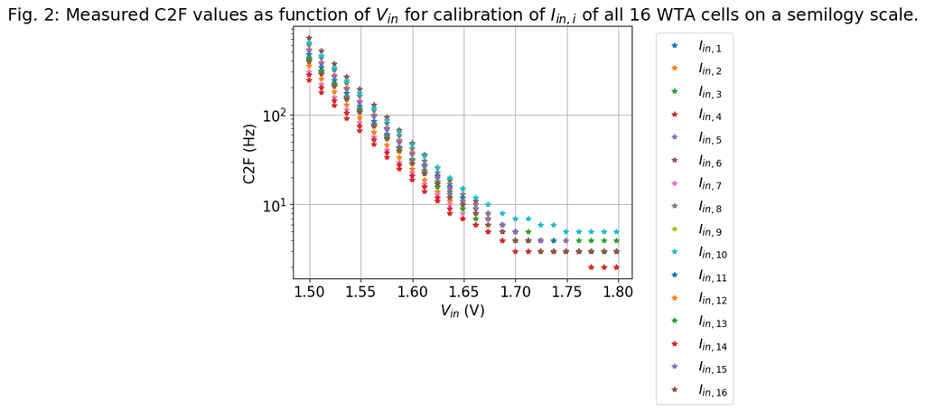

```python
import matplotlib.pyplot as plt
import numpy as np
plt.rcParams.update({'font.size': 15})

Vi = np.loadtxt('./data/Vi_ex_4_2_3.csv',delimiter=',')
c2f = np.loadtxt('./data/c2f_ex_4_2_3.csv',delimiter=',')
plt.semilogy(Vi,np.transpose(c2f),'*')

plt.xlabel('$V_{in}$ (V)')
plt.ylabel('C2F (Hz)')
plt.legend(['${I_{in,1}}$','${I_{in,2}}$','${I_{in,3}}$','${I_{in,4}}$','${I_{in,5}}$','${I_{in,6}}$','${I_{in,7}}$','${I_{in,8}}$','${I_{in,9}}$','${I_{in,10}}$','${I_{in,11}}$','${I_{in,12}}$','${I_{in,13}}$','${I_{in,14}}$','${I_{in,15}}$','${I_{in,16}}$'],prop={'size': 14},bbox_to_anchor=(1.05, 1),loc='upper left')
plt.title('Fig. 2: Measured C2F values as function of $V_{in}$ for calibration of $I_{in,i}$ of all 16 WTA cells on a semilogy scale.')
plt.grid()
plt.show()
```

In Fig. 2, the measured C2F values for the calibration of the input current $I_{in,i}$ of all 16 WTA cells are plotted on a semilogy scale over the input voltage in the range $V_{in} \in[1.5\text{V},1.8\text{V}]$.

The output feedback, excitatory lateral coupling and inhibitory lateral coupling have been turned off in this measurment, implying that $I_{in,i} = I_{all}$.

- Fit data

```python
c2f = np.loadtxt('./data/c2f_ex_4_2_3.csv',delimiter=',')
Vi = np.loadtxt('./data/Vi_ex_4_2_3.csv',delimiter=',')

fit_from = 18

Iin_ch1 = np.polyfit(Vi[fit_from:],np.log(c2f_ch1[2]+ c2f_ch1[1]*c2f[0][fit_from:]+c2f_ch1[0]*c2f[0][fit_from:]**2),1)
Iin_ch2 = np.polyfit(Vi[fit_from:],np.log(c2f_ch2[2]+ c2f_ch2[1]*c2f[1][fit_from:]+c2f_ch2[0]*c2f[1][fit_from:]**2),1)
Iin_ch3 = np.polyfit(Vi[fit_from:],np.log(c2f_ch3[2]+ c2f_ch3[1]*c2f[2][fit_from:]+c2f_ch3[0]*c2f[2][fit_from:]**2),1)
Iin_ch4 = np.polyfit(Vi[fit_from:],np.log(c2f_ch4[2]+ c2f_ch4[1]*c2f[3][fit_from:]+c2f_ch4[0]*c2f[3][fit_from:]**2),1)
Iin_ch5 = np.polyfit(Vi[fit_from:],np.log(c2f_ch5[2]+ c2f_ch5[1]*c2f[4][fit_from:]+c2f_ch5[0]*c2f[4][fit_from:]**2),1)
Iin_ch6 = np.polyfit(Vi[fit_from:],np.log(c2f_ch6[2]+ c2f_ch6[1]*c2f[5][fit_from:]+c2f_ch6[0]*c2f[5][fit_from:]**2),1)
Iin_ch7 = np.polyfit(Vi[fit_from:],np.log(c2f_ch7[2]+ c2f_ch7[1]*c2f[6][fit_from:]+c2f_ch7[0]*c2f[6][fit_from:]**2),1)
Iin_ch8 = np.polyfit(Vi[fit_from:],np.log(c2f_ch8[2]+ c2f_ch8[1]*c2f[7][fit_from:]+c2f_ch8[0]*c2f[7][fit_from:]**2),1)
Iin_ch9 = np.polyfit(Vi[fit_from:],np.log(c2f_ch9[2]+ c2f_ch9[1]*c2f[8][fit_from:]+c2f_ch9[0]*c2f[8][fit_from:]**2),1)
Iin_ch10 = np.polyfit(Vi[fit_from:],np.log(c2f_ch10[2]+ c2f_ch10[1]*c2f[9][fit_from:]+c2f_ch10[0]*c2f[9][fit_from:]**2),1)
Iin_ch11 = np.polyfit(Vi[fit_from:],np.log(c2f_ch11[2]+ c2f_ch11[1]*c2f[10][fit_from:]+c2f_ch11[0]*c2f[10][fit_from:]**2),1)
Iin_ch12 = np.polyfit(Vi[fit_from:],np.log(c2f_ch12[2]+ c2f_ch12[1]*c2f[11][fit_from:]+c2f_ch12[0]*c2f[11][fit_from:]**2),1)
Iin_ch13 = np.polyfit(Vi[fit_from:],np.log(c2f_ch13[2]+ c2f_ch13[1]*c2f[12][fit_from:]+c2f_ch13[0]*c2f[12][fit_from:]**2),1)
Iin_ch14 = np.polyfit(Vi[fit_from:],np.log(c2f_ch14[2]+ c2f_ch14[1]*c2f[13][fit_from:]+c2f_ch14[0]*c2f[13][fit_from:]**2),1)
Iin_ch15 = np.polyfit(Vi[fit_from:],np.log(c2f_ch15[2]+ c2f_ch15[1]*c2f[14][fit_from:]+c2f_ch15[0]*c2f[14][fit_from:]**2),1)
Iin_ch16 = np.polyfit(Vi[fit_from:],np.log(c2f_ch16[2]+ c2f_ch16[1]*c2f[15][fit_from:]+c2f_ch16[0]*c2f[15][fit_from:]**2),1)

print(Iin_ch1)
print(Iin_ch2)
print(Iin_ch3)

Vdd = 1.8
Ut  = 0.025
I0_K = np.zeros([16,2])  # store I_0 and k
for i in range(16):
    exec('I0_K['+str(i)+'][1] = -Iin_ch'+str(i+1)+'[0]*Ut')
    exec('I0_K['+str(i)+'][0] = np.exp(Iin_ch'+str(i+1)+'[1] - Vdd*I0_K['+str(i)+'][1]/Ut)')
#     exec('I0_K['+str(i)+'][0] = np.exp(Iin_ch'+str(i+1)+'[1] - Vdd/Ut)')

print(I0_K)
```

```
[-28.42490791  21.91556866]
[-28.53539961  21.7217724 ]
[-27.74158815  21.09546312]
[[1.98246425e-13 7.10622698e-01]
 [1.33864688e-13 7.13384990e-01]
 [2.98682416e-13 6.93539704e-01]
 [8.41273775e-14 7.40405940e-01]
 [2.30534356e-13 6.85611220e-01]
 [4.91518118e-13 6.97415554e-01]
 [1.59910843e-13 6.99916167e-01]
 [3.75217759e-13 6.83762192e-01]
 [1.78254065e-13 6.96935332e-01]
 [3.21824381e-13 7.04281944e-01]
 [2.72696473e-13 6.90667593e-01]
 [3.68814175e-13 7.07173323e-01]
 [1.92577682e-13 6.84736070e-01]
 [           nan            nan]
 [2.84130069e-13 6.92279866e-01]
 [1.86747966e-13 7.08500758e-01]]
```

**Hint: Methods (need to understand):**

By linearly fitting $\ln(I_{in})$ and referencing the equation for the input current given at the beggining of 4.2.3

PFET in saturation (**all voltages are referenced to N-well, Vwell=Vdd**): $I_{in} = I_0 e^{ \dfrac{{-\kappa V_{g}} + V_{s}} {U_T} } = I_0 e^{ \dfrac{{-\kappa (V_{in} - V_{dd})} + (V_{dd}- V_{dd})} {U_T} } = I_0 e^{ \dfrac{{\kappa (V_{dd} - V_{in})}} {U_T}}$,

the parameters $\kappa$ and $I_0$ of all input transitors can be extracted. The corresponding relationships can be obtained by comparing the analytical description of the input current with the linearly interpolated function

$\ln(I_{in})= I_{in,fit}$

$\Rightarrow \ln(I_0) + \dfrac{\kappa}{U_T}V_{dd} - \dfrac{\kappa}{U_T}V_{in} = m_{i} V_{in} + b_{i} $ <- fit equation

This yields

$m_i = - \dfrac{\kappa}{U_T} \Rightarrow \kappa = - m_i U_T \quad$ and

$b_i = \ln(I_0) + \dfrac{\kappa}{U_T}V_{dd} \Rightarrow I_0 = e^{\displaystyle b_i - \dfrac{\kappa}{U_T}V_{dd}}.$

Shown on the example of cell 1, you can know $I_{in} =e^{ m_{i} V_{in} + b_{i}}$.

## 4.3 Calibration of the individual bias currents (optional)

If we repeat 4.1 but with $V_c$ between cells isolated (Hint: by setting $V_{inh}$ to proper value), we could measure individual $I_b$.

# 5 Basic WTA behavior

In this experiment, we will observe the winner–take–all network in action. We will only use cell 0 and 1 and disable all other cells.

## 5.1 Set fixed voltages

- What value should bias `WTA_VGAIN_P` take?

```python
p.send_coach_events([pyplane.Coach.generate_biasgen_event(\
pyplane.Coach.BiasAddress.WTA_VGAIN_P,\
pyplane.Coach.BiasType.P, \
pyplane.Coach.BiasGenMasterCurrent.I30nA, 255)])
```

- What value should bias `WTA_VEX_N` take?

```python
p.send_coach_events([pyplane.Coach.generate_biasgen_event(\
pyplane.Coach.BiasAddress.WTA_VEX_N,\
pyplane.Coach.BiasType.N, \
pyplane.Coach.BiasGenMasterCurrent.I30nA, 0)])
```

The excitatory lateral coupling has been turned off by setting $V_{ex}= 0 \text{V}$.

- What value should bias `WTA_VINH_N` take?

```python
p.send_coach_events([pyplane.Coach.generate_biasgen_event(\
pyplane.Coach.BiasAddress.WTA_VINH_N,\
pyplane.Coach.BiasType.P, \
pyplane.Coach.BiasGenMasterCurrent.I30nA, 0)])
```

- What value should bias `WTA_VB_N` take?

```python
p.send_coach_events([pyplane.Coach.generate_biasgen_event(\
pyplane.Coach.BiasAddress.WTA_VB_N,\
pyplane.Coach.BiasType.N, \
pyplane.Coach.BiasGenMasterCurrent.I460pA, 120)])
```

The bias current has been set to

$I_b = w\dfrac{BG_{\text{fine}}}{256}I_{BG_{\text{master}}} = 3\cdot \dfrac{120}{256}\cdot 460 \approx 646 (pA)$.

- What value should the $V_{in}$ of Cell 2 - Cell15 take in order to disable them?

  > 1.8 V (pfet)

```python
for i in range(2, 16):
    p.set_voltage(eval('pyplane.DacChannel.AIN' + str(i)), 1.8)
    time.sleep(0.2)
```

> Cells 2 - 15 can be turned off by setting their respective input voltages to 1.8 (as the corresponding transistors are pFETs)

## 5.2 Data aquisition

- Fix $V_{in,1}$ to a value and sweep $V_{in,0}$ from above $V_{in,1}$ to below $V_{in,1}$ then to above $V_{in,1}$ again and observe the two $V_{out}$ and $I_{out}$.

**Important: never set any $V_{in}$ below 1.5 V**

```python
# Select Line2 to read Iout
p.send_coach_events([pyplane.Coach.generate_aerc_event(
    pyplane.pyplane.Coach.CurrentOutputSelect.SelectLine2,
    pyplane.Coach.VoltageOutputSelect.SelectLine0,
    pyplane.Coach.VoltageInputSelect.SelectLine0,
    pyplane.Coach.SynapseSelect.NoneSelected,0)])
```

```python
N_samples = 50

Vin1 = 1.6  # ??? V
p.set_voltage(pyplane.DacChannel.AIN1,Vin1)
time.sleep(0.2)
Vin1_actual = p.get_set_voltage(pyplane.DacChannel.AIN1)

Vin0_set = np.concatenate((np.linspace(1.8, 1.5, 25),np.linspace(1.5, 1.8, 25)))  ## ??? is larger than 1.5

Vi0 = np.zeros(N_samples)
Vout0 = np.zeros(N_samples)
Vout1 = np.zeros(N_samples)
c2f_Iout = np.zeros([16, N_samples])
#c2f_Iall = np.zeros([16, N_samples])

for j in range(N_samples):
    p.set_voltage(pyplane.DacChannel.AIN0, Vin0_set[j])

    time.sleep(0.2)

    Vi0[j] = p.get_set_voltage(pyplane.DacChannel.AIN0)

    time.sleep(0.1)

    Vout0[j] = p.read_voltage(pyplane.AdcChannel.AOUT15)  # go back 3.4 to check the note of schematic, figure out why AOUT15 here
#     time.sleep(0.1)
    Vout1[j] = p.read_voltage(pyplane.AdcChannel.AOUT14)  # go back 3.4 to check the note of schematic, figure out why AOUT14 here
#     time.sleep(0.1)

    # Measure Iout by c2f
    c2f_Iout[:,j] = p.read_c2f_output(0.1)

    #Measure Iall
    #p.send_coach_event(pyplane.Coach.generate_aerc_event(
   # pyplane.pyplane.Coach.CurrentOutputSelect.SelectLine3,
    #pyplane.Coach.VoltageOutputSelect.SelectLine0,
    #pyplane.Coach.VoltageInputSelect.SelectLine0,
    #pyplane.Coach.SynapseSelect.NoneSelected,0))
```

- Save data

```python
np.savetxt('./data/Vi0_ex_5_2.csv', Vi0, delimiter=',')
np.savetxt('./data/Vout0_ex_5_2.csv', Vout0, delimiter=',')
np.savetxt('./data/Vout1_ex_5_2.csv', Vout1, delimiter=',')
np.savetxt('./data/c2f_Iout_ex_5_2.csv', c2f_Iout, delimiter=',')
# np.savetxt('./data/c2f_Iall_ex_5_2.csv', c2f_Iall, delimiter=',')
```

- Plot data (you may want to plot the axes in a proper range that can zoom in the transition region)

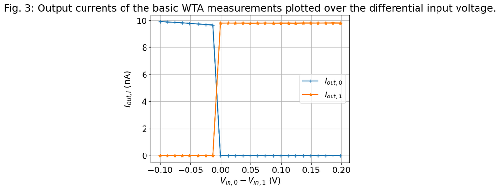

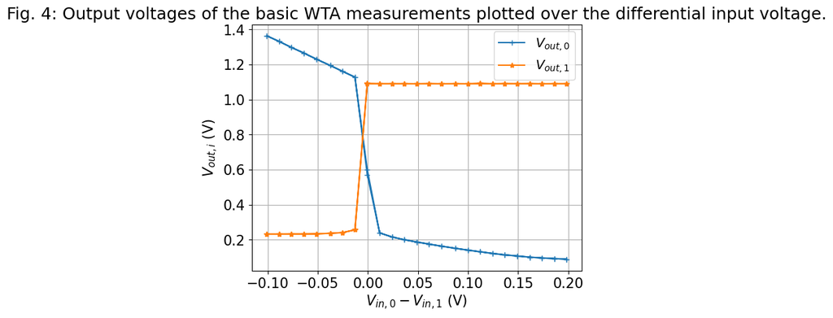

```python
import matplotlib.pyplot as plt
import numpy as np
plt.rcParams.update({'font.size': 15})

Vi0 = np.loadtxt('./data/Vi0_ex_5_2.csv',  delimiter=',')
Vout0 = np.loadtxt('./data/Vout0_ex_5_2.csv',  delimiter=',')
Vout1 = np.loadtxt('./data/Vout1_ex_5_2.csv',  delimiter=',')
c2f_Iout = np.loadtxt('./data/c2f_Iout_ex_5_2.csv',  delimiter=',')
# c2f_Iall = np.loadtxt('./data/c2f_Iall_ex_5_2.csv',  delimiter=',')


# I(f) function to convert frequcy to current, using factors from section 4.1
Iout0 = c2f_ch1[2]+ c2f_ch1[1]*c2f_Iout[0,:]+c2f_ch1[0]*c2f_Iout[0,:]**2
Iout1 = c2f_ch2[2]+ c2f_ch2[1]*c2f_Iout[1,:]+c2f_ch2[0]*c2f_Iout[1,:]**2

# Plot output current vs. the difference between input voltages
plt.plot(Vi0-Vin1,Iout0*10**9,'+-')
plt.plot(Vi0-Vin1,Iout1*10**9,'*-')

plt.xlabel('$V_{in,0}-V_{in,1}$ (V)')
plt.ylabel('$I_{out,i}$ (nA)')
plt.legend(['${I_{out,0}}$','${I_{out,1}}$'],prop={'size': 14})
plt.title('Fig. 3: Output currents of the basic WTA measurements plotted over the differential input voltage.')
plt.grid()
plt.show()

plt.legend(['${I_{out,0}}$','${I_{out,1}}$'],prop={'size': 14})
plt.plot(Vi0-Vin1,Vout0,'+-')
plt.plot(Vi0-Vin1,Vout1,'*-')

plt.xlabel('$V_{in,0}-V_{in,1}$ (V)')
plt.ylabel('$V_{out,i}$ (V)')
plt.legend(['${V_{out,0}}$','${V_{out,1}}$'],prop={'size': 14})
plt.title('Fig. 4: Output voltages of the basic WTA measurements plotted over the differential input voltage.')
plt.grid()
plt.show()
```

**Conclusion of your experiment**

> We can see that for the output current we get that the winning cell will shoot to Ib and the losing cell will remain at 0. We can also note that Iout should be Ib/2 when $\Delta V =0$, but there is a slight shift, probably due to transistor mismatch.

> For the output voltages, we can observe the same as for the output currents, except Vout0 has a negative slope.

## 5.3 Different bias currents

**Question: If we change the bias current $I_b$, what will happen?**

# 6 Hysteretic WTA behavior

In this experiment, we will observe the winner–take–all network with hysteresis. This implies a "memory" effect.

We will still use only cell 0 and 1 and disable all other cells.

## 6.1 Set fixed voltages

- What value should bias `WTA_VEX_N` take?

```python
p.send_coach_events([pyplane.Coach.generate_biasgen_event(\
pyplane.Coach.BiasAddress.WTA_VEX_N,\
pyplane.Coach.BiasType.N, \
pyplane.Coach.BiasGenMasterCurrent.I60pA, 0)])
```

- What value should bias `WTA_VINH_N` take?

```python
p.send_coach_events([pyplane.Coach.generate_biasgen_event(\
pyplane.Coach.BiasAddress.WTA_VINH_N,\
pyplane.Coach.BiasType.P, \
pyplane.Coach.BiasGenMasterCurrent.I60pA, 0)])
```

- What value should bias `WTA_VB_N` take?

```python
p.send_coach_events([pyplane.Coach.generate_biasgen_event(\
pyplane.Coach.BiasAddress.WTA_VB_N,\
pyplane.Coach.BiasType.N, \
pyplane.Coach.BiasGenMasterCurrent.I460pA, 64)])
```

The bias current has been set to $I_b \approx 345\text{pA}$.

- What value should the $V_{in}$ of Cell 2 - Cell15 take in order to disable them?

```python
for i in range(2, 16):
    p.set_voltage(eval('pyplane.DacChannel.AIN' + str(i)), 1.8)
    time.sleep(0.2)
```

Cells 2 - 15 can be turned off by setting their respective input voltages to $V_{dd}$ (as the corresponding transistors are pFETs)

## 6.2 Data aquisition

- What value should bias `WTA_VGAIN_P` take?

```python
p.send_coach_events([pyplane.Coach.generate_biasgen_event(\
pyplane.Coach.BiasAddress.WTA_VGAIN_P,\
pyplane.Coach.BiasType.P, \
pyplane.Coach.BiasGenMasterCurrent.I60pA, 30)])
```

- Fix $V_{in,1}$ to a value and sweep $V_{in,0}$ from above $V_{in,1}$ to below $V_{in,1}$ then to above $V_{in,1}$ again and observe the two $V_{out}$, $I_{out}$ and $I_{all}$.

**Important: never set any $V_{in}$ below 1.5 V**

```python
p.send_coach_events([pyplane.Coach.generate_aerc_event(
    pyplane.pyplane.Coach.CurrentOutputSelect.SelectLine2,
    pyplane.Coach.VoltageOutputSelect.SelectLine0,
    pyplane.Coach.VoltageInputSelect.SelectLine0,
    pyplane.Coach.SynapseSelect.NoneSelected,0)])
```

```python
N_samples = 50

Vin1 = 1.6
p.set_voltage(pyplane.DacChannel.AIN1,Vin1)
time.sleep(0.5)
Vin1_actual = p.get_set_voltage(pyplane.DacChannel.AIN1)

Vin0_set = np.concatenate((np.linspace(1.5, 1.8, 25),np.linspace(1.8, 1.5, 25)))

Vi0 = np.zeros(N_samples)
Vout0 = np.zeros(N_samples)
Vout1 = np.zeros(N_samples)
c2f_Iout = np.zeros([16, N_samples])
#c2f_Iall = np.zeros([16, N_samples])

for j in range(N_samples):
    p.set_voltage(pyplane.DacChannel.AIN0, Vin0_set[j])

    time.sleep(0.2)

    Vi0[j] = p.get_set_voltage(pyplane.DacChannel.AIN0)
    Vout0[j] = p.read_voltage(pyplane.AdcChannel.AOUT15)
#     time.sleep(0.1)
    Vout1[j] = p.read_voltage(pyplane.AdcChannel.AOUT14)
#     time.sleep(0.1)

    # Measure Iout
    c2f_Iout[:,j] = p.read_c2f_output(0.1)   #p.read_all_sampled_c2fs()
```

```python
# p.send_coach_events([pyplane.Coach.generate_aerc_event(
# pyplane.pyplane.Coach.CurrentOutputSelect.SelectLine3,
# pyplane.Coach.VoltageOutputSelect.SelectLine0,
# pyplane.Coach.VoltageInputSelect.SelectLine0,
# pyplane.Coach.SynapseSelect.NoneSelected,0)])
```

```python
# N_samples = 50

# Vin1 = ???
# p.set_voltage(pyplane.DacChannel.AIN1,Vin1)
# time.sleep(0.5)
# Vin1_actual = p.get_set_voltage(pyplane.DacChannel.AIN1)

# Vin0_set = np.concatenate((np.linspace(???, ???, 25),np.linspace(???, ???, 25)))

# c2f_Iall = np.zeros([16, N_samples])

# for j in range(N_samples):
#     p.set_voltage(pyplane.DacChannel.AIN0, Vin0_set[j])

#     time.sleep(0.2)

#     #Measure Iall
#     c2f_Iall[:,j] = p.read_c2f_output(0.1)  #p.read_all_sampled_c2fs()

# p.set_sampling_mode(pyplane.SamplingMode.Off)
```

- Save data

```python
np.savetxt('./data/Vi0_ex_6_2_30.csv', Vi0, delimiter=',')
np.savetxt('./data/Vout0_ex_6_2_30.csv', Vout0, delimiter=',')
np.savetxt('./data/Vout1_ex_6_2_30.csv', Vout1, delimiter=',')
np.savetxt('./data/c2f_Iout_ex_6_2_30.csv', c2f_Iout, delimiter=',')
#np.savetxt('./data/c2f_Iall_ex_6_2.csv', c2f_Iall, delimiter=',')
```

- Plot data (you may want to plot the axes in a proper range that can zoom in the transition region)

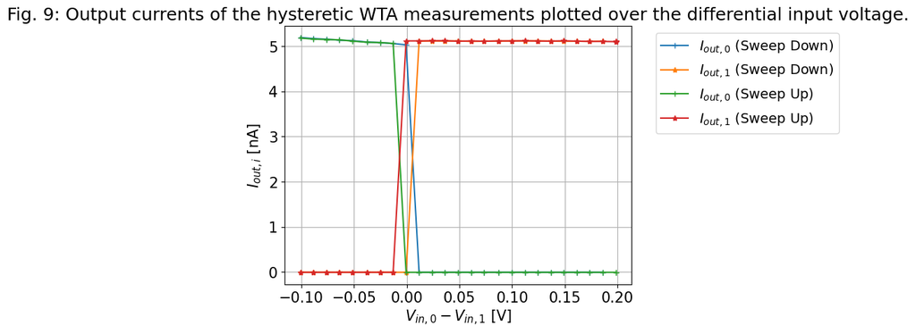

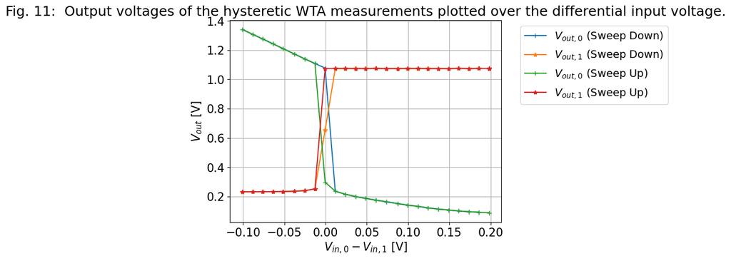

```python
import matplotlib.pyplot as plt
import numpy as np
plt.rcParams.update({'font.size': 15})

Vin1 = 1.6
Vi0 = np.loadtxt('./data/Vi0_ex_6_2.csv',  delimiter=',')
Vout0 = np.loadtxt('./data/Vout0_ex_6_2.csv',  delimiter=',')
Vout1 = np.loadtxt('./data/Vout1_ex_6_2.csv',  delimiter=',')
c2f_Iout = np.loadtxt('./data/c2f_Iout_ex_6_2.csv',  delimiter=',')
#c2f_Iall = np.loadtxt('./data/c2f_Iall_ex_6_2.csv',  delimiter=',')

Iout0 = c2f_ch1[2]+ c2f_ch1[1]*c2f_Iout[0,:]+c2f_ch1[0]*c2f_Iout[0,:]**2
Iout1 = c2f_ch2[2]+ c2f_ch2[1]*c2f_Iout[1,:]+c2f_ch2[0]*c2f_Iout[1,:]**2

plt.plot((Vi0-Vin1)[:24],(Iout0[:24])*10**9,'+-')
plt.plot((Vi0-Vin1)[:24],(Iout1[:24])*10**9,'*-')
plt.plot((Vi0-Vin1)[24:],(Iout0[24:])*10**9,'+-')
plt.plot((Vi0-Vin1)[24:],(Iout1[24:])*10**9,'*-')
plt.legend(['${I_{out,0}}$ (Sweep Down)','${I_{out,1}}$ (Sweep Down)','${I_{out,0}}$ (Sweep Up)','${I_{out,1}}$ (Sweep Up)'],prop={'size': 14},bbox_to_anchor=(1.05, 1),loc='upper left')
plt.xlabel('$V_{in,0}-V_{in,1}$ [V]')
plt.ylabel('$I_{out,i}$ [nA]')

plt.title('Fig. 9: Output currents of the hysteretic WTA measurements plotted over the differential input voltage.')
plt.grid()
plt.show()

#Iall0 = c2f_ch1[2]+ c2f_ch1[1]*c2f_Iall[0,:]+c2f_ch1[0]*c2f_Iall[0,:]**2
#Iall1 = c2f_ch2[2]+ c2f_ch2[1]*c2f_Iall[1,:]+c2f_ch2[0]*c2f_Iall[1,:]**2

# print(Iall0)

# plt.semilogy((Vi0-Vin1)[:24],Iall0[:24],'+-')
# plt.semilogy((Vi0-Vin1)[:24],Iall1[:24],'*-')
# plt.semilogy((Vi0-Vin1)[24:],Iall0[24:],'+-')
# plt.semilogy((Vi0-Vin1)[24:],Iall1[24:],'*-')

# plt.xlabel('$V_{in,0}-V_{in,1}$ [V]')
# plt.ylabel('$I_{all,i}$ [A]')
# plt.legend(['${I_{all,0}}$ (Sweep Down)','${I_{all,1}}$ (Sweep Down)','${I_{all,0}}$ (Sweep Up)','${I_{all,1}}$ (Sweep Up)'],prop={'size': 14},bbox_to_anchor=(1.05, 1),loc='upper left')
# plt.title('Fig. 10: Net input currents of the hysteretic WTA measurements plotted over the differential input voltage.')
# plt.grid()
# plt.show()

plt.plot((Vi0-Vin1)[:24],Vout0[:24],'+-')
plt.plot((Vi0-Vin1)[:24],Vout1[:24],'*-')
plt.plot((Vi0-Vin1)[24:],Vout0[24:],'+-')
plt.plot((Vi0-Vin1)[24:],Vout1[24:],'*-')
plt.xlabel('$V_{in,0}-V_{in,1}$ [V]')
plt.ylabel('$V_{out}$ [V]')
plt.legend(['${V_{out,0}}$ (Sweep Down)','${V_{out,1}}$ (Sweep Down)','${V_{out,0}}$ (Sweep Up)','${V_{out,1}}$ (Sweep Up)'],prop={'size': 14},bbox_to_anchor=(1.05, 1),loc='upper left')
plt.title('Fig. 11:  Output voltages of the hysteretic WTA measurements plotted over the differential input voltage.')
plt.grid()
plt.show()
```

**Conclusion of your experiment**

> When increasing the Hysterisis current, we get a more important Hysterisis effect.

## 6.3 Different gain voltages

**Repeat 6.2 with two differnt $V_{gain}$ and compare.**

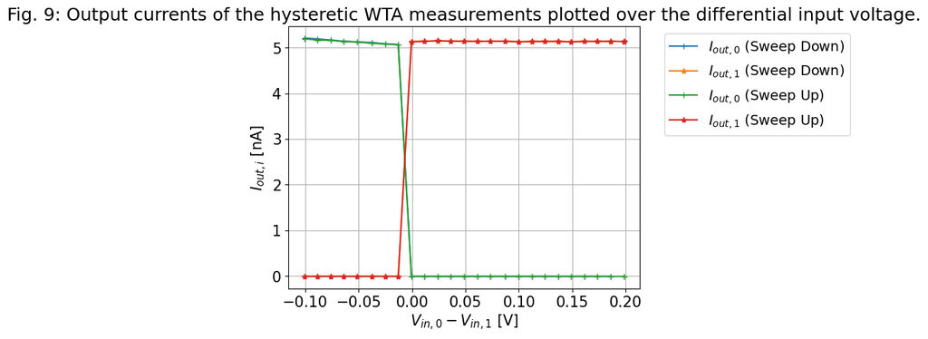

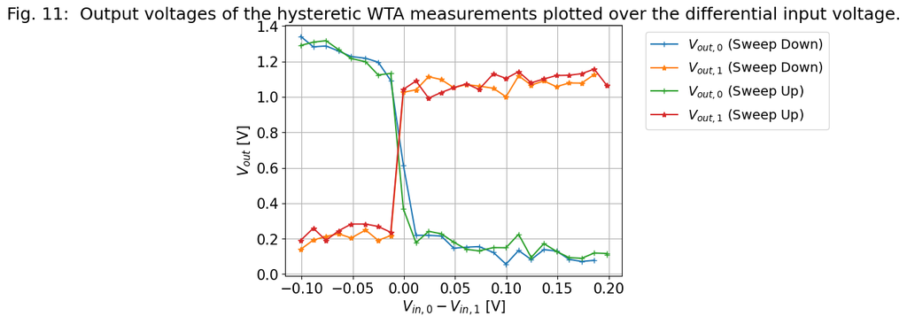

```python
import matplotlib.pyplot as plt
import numpy as np
plt.rcParams.update({'font.size': 15})

Vin1 = 1.6
Vi0 = np.loadtxt('./data/Vi0_ex_6_2_8.csv',  delimiter=',')
Vout0 = np.loadtxt('./data/Vout0_ex_6_2_8.csv',  delimiter=',')
Vout1 = np.loadtxt('./data/Vout1_ex_6_2_8.csv',  delimiter=',')
c2f_Iout = np.loadtxt('./data/c2f_Iout_ex_6_2_8.csv',  delimiter=',')
#c2f_Iall = np.loadtxt('./data/c2f_Iall_ex_6_2.csv',  delimiter=',')

Iout0 = c2f_ch1[2]+ c2f_ch1[1]*c2f_Iout[0,:]+c2f_ch1[0]*c2f_Iout[0,:]**2
Iout1 = c2f_ch2[2]+ c2f_ch2[1]*c2f_Iout[1,:]+c2f_ch2[0]*c2f_Iout[1,:]**2

plt.plot((Vi0-Vin1)[:24],(Iout0[:24])*10**9,'+-')
plt.plot((Vi0-Vin1)[:24],(Iout1[:24])*10**9,'*-')
plt.plot((Vi0-Vin1)[24:],(Iout0[24:])*10**9,'+-')
plt.plot((Vi0-Vin1)[24:],(Iout1[24:])*10**9,'*-')
plt.legend(['${I_{out,0}}$ (Sweep Down)','${I_{out,1}}$ (Sweep Down)','${I_{out,0}}$ (Sweep Up)','${I_{out,1}}$ (Sweep Up)'],prop={'size': 14},bbox_to_anchor=(1.05, 1),loc='upper left')
plt.xlabel('$V_{in,0}-V_{in,1}$ [V]')
plt.ylabel('$I_{out,i}$ [nA]')

plt.title('Fig. 9: Output currents of the hysteretic WTA measurements plotted over the differential input voltage.')
plt.grid()
plt.show()

#Iall0 = c2f_ch1[2]+ c2f_ch1[1]*c2f_Iall[0,:]+c2f_ch1[0]*c2f_Iall[0,:]**2
#Iall1 = c2f_ch2[2]+ c2f_ch2[1]*c2f_Iall[1,:]+c2f_ch2[0]*c2f_Iall[1,:]**2

# print(Iall0)

# plt.semilogy((Vi0-Vin1)[:24],Iall0[:24],'+-')
# plt.semilogy((Vi0-Vin1)[:24],Iall1[:24],'*-')
# plt.semilogy((Vi0-Vin1)[24:],Iall0[24:],'+-')
# plt.semilogy((Vi0-Vin1)[24:],Iall1[24:],'*-')

# plt.xlabel('$V_{in,0}-V_{in,1}$ [V]')
# plt.ylabel('$I_{all,i}$ [A]')
# plt.legend(['${I_{all,0}}$ (Sweep Down)','${I_{all,1}}$ (Sweep Down)','${I_{all,0}}$ (Sweep Up)','${I_{all,1}}$ (Sweep Up)'],prop={'size': 14},bbox_to_anchor=(1.05, 1),loc='upper left')
# plt.title('Fig. 10: Net input currents of the hysteretic WTA measurements plotted over the differential input voltage.')
# plt.grid()
# plt.show()

plt.plot((Vi0-Vin1)[:24],Vout0[:24],'+-')
plt.plot((Vi0-Vin1)[:24],Vout1[:24],'*-')
plt.plot((Vi0-Vin1)[24:],Vout0[24:],'+-')
plt.plot((Vi0-Vin1)[24:],Vout1[24:],'*-')
plt.xlabel('$V_{in,0}-V_{in,1}$ [V]')
plt.ylabel('$V_{out}$ [V]')
plt.legend(['${V_{out,0}}$ (Sweep Down)','${V_{out,1}}$ (Sweep Down)','${V_{out,0}}$ (Sweep Up)','${V_{out,1}}$ (Sweep Up)'],prop={'size': 14},bbox_to_anchor=(1.05, 1),loc='upper left')
plt.title('Fig. 11:  Output voltages of the hysteretic WTA measurements plotted over the differential input voltage.')
plt.grid()
plt.show()
```

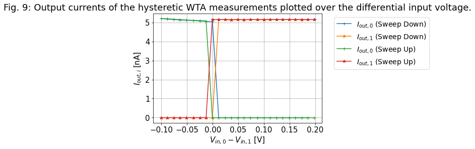

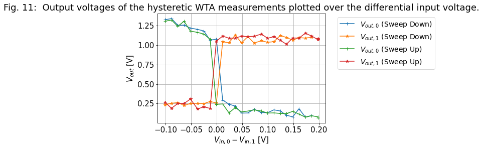

```python
import matplotlib.pyplot as plt
import numpy as np
plt.rcParams.update({'font.size': 15})

Vin1 = 1.6
Vi0 = np.loadtxt('./data/Vi0_ex_6_2_10.csv',  delimiter=',')
Vout0 = np.loadtxt('./data/Vout0_ex_6_2_10.csv',  delimiter=',')
Vout1 = np.loadtxt('./data/Vout1_ex_6_2_10.csv',  delimiter=',')
c2f_Iout = np.loadtxt('./data/c2f_Iout_ex_6_2_10.csv',  delimiter=',')
#c2f_Iall = np.loadtxt('./data/c2f_Iall_ex_6_2.csv',  delimiter=',')

Iout0 = c2f_ch1[2]+ c2f_ch1[1]*c2f_Iout[0,:]+c2f_ch1[0]*c2f_Iout[0,:]**2
Iout1 = c2f_ch2[2]+ c2f_ch2[1]*c2f_Iout[1,:]+c2f_ch2[0]*c2f_Iout[1,:]**2

plt.plot((Vi0-Vin1)[:24],(Iout0[:24])*10**9,'+-')
plt.plot((Vi0-Vin1)[:24],(Iout1[:24])*10**9,'*-')
plt.plot((Vi0-Vin1)[24:],(Iout0[24:])*10**9,'+-')
plt.plot((Vi0-Vin1)[24:],(Iout1[24:])*10**9,'*-')
plt.legend(['${I_{out,0}}$ (Sweep Down)','${I_{out,1}}$ (Sweep Down)','${I_{out,0}}$ (Sweep Up)','${I_{out,1}}$ (Sweep Up)'],prop={'size': 14},bbox_to_anchor=(1.05, 1),loc='upper left')
plt.xlabel('$V_{in,0}-V_{in,1}$ [V]')
plt.ylabel('$I_{out,i}$ [nA]')

plt.title('Fig. 9: Output currents of the hysteretic WTA measurements plotted over the differential input voltage.')
plt.grid()
plt.show()

#Iall0 = c2f_ch1[2]+ c2f_ch1[1]*c2f_Iall[0,:]+c2f_ch1[0]*c2f_Iall[0,:]**2
#Iall1 = c2f_ch2[2]+ c2f_ch2[1]*c2f_Iall[1,:]+c2f_ch2[0]*c2f_Iall[1,:]**2

# print(Iall0)

# plt.semilogy((Vi0-Vin1)[:24],Iall0[:24],'+-')
# plt.semilogy((Vi0-Vin1)[:24],Iall1[:24],'*-')
# plt.semilogy((Vi0-Vin1)[24:],Iall0[24:],'+-')
# plt.semilogy((Vi0-Vin1)[24:],Iall1[24:],'*-')
plt.plot((Vi0-Vin1)[:24],Vout0[:24],'+-')
plt.plot((Vi0-Vin1)[:24],Vout1[:24],'*-')
plt.plot((Vi0-Vin1)[24:],Vout0[24:],'+-')
plt.plot((Vi0-Vin1)[24:],Vout1[24:],'*-')
plt.xlabel('$V_{in,0}-V_{in,1}$ [V]')
plt.ylabel('$V_{out}$ [V]')
plt.legend(['${V_{out,0}}$ (Sweep Down)','${V_{out,1}}$ (Sweep Down)','${V_{out,0}}$ (Sweep Up)','${V_{out,1}}$ (Sweep Up)'],prop={'size': 14},bbox_to_anchor=(1.05, 1),loc='upper left')
plt.title('Fig. 11:  Output voltages of the hysteretic WTA measurements plotted over the differential input voltage.')
plt.grid()
plt.show()
```

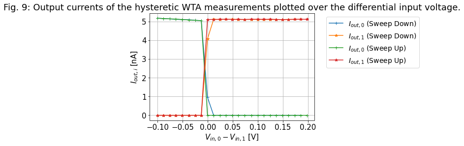

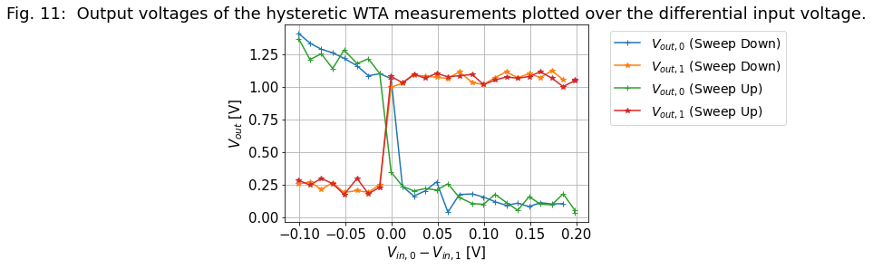

```python
import matplotlib.pyplot as plt
import numpy as np
plt.rcParams.update({'font.size': 15})

Vin1 = 1.6
Vi0 = np.loadtxt('./data/Vi0_ex_6_2_30.csv',  delimiter=',')
Vout0 = np.loadtxt('./data/Vout0_ex_6_2_30.csv',  delimiter=',')
Vout1 = np.loadtxt('./data/Vout1_ex_6_2_30.csv',  delimiter=',')
c2f_Iout = np.loadtxt('./data/c2f_Iout_ex_6_2_30.csv',  delimiter=',')
#c2f_Iall = np.loadtxt('./data/c2f_Iall_ex_6_2.csv',  delimiter=',')

Iout0 = c2f_ch1[2]+ c2f_ch1[1]*c2f_Iout[0,:]+c2f_ch1[0]*c2f_Iout[0,:]**2
Iout1 = c2f_ch2[2]+ c2f_ch2[1]*c2f_Iout[1,:]+c2f_ch2[0]*c2f_Iout[1,:]**2

plt.plot((Vi0-Vin1)[:24],(Iout0[:24])*10**9,'+-')
plt.plot((Vi0-Vin1)[:24],(Iout1[:24])*10**9,'*-')
plt.plot((Vi0-Vin1)[24:],(Iout0[24:])*10**9,'+-')
plt.plot((Vi0-Vin1)[24:],(Iout1[24:])*10**9,'*-')
plt.legend(['${I_{out,0}}$ (Sweep Down)','${I_{out,1}}$ (Sweep Down)','${I_{out,0}}$ (Sweep Up)','${I_{out,1}}$ (Sweep Up)'],prop={'size': 14},bbox_to_anchor=(1.05, 1),loc='upper left')
plt.xlabel('$V_{in,0}-V_{in,1}$ [V]')
plt.ylabel('$I_{out,i}$ [nA]')

plt.title('Fig. 9: Output currents of the hysteretic WTA measurements plotted over the differential input voltage.')
plt.grid()
plt.show()

#Iall0 = c2f_ch1[2]+ c2f_ch1[1]*c2f_Iall[0,:]+c2f_ch1[0]*c2f_Iall[0,:]**2
#Iall1 = c2f_ch2[2]+ c2f_ch2[1]*c2f_Iall[1,:]+c2f_ch2[0]*c2f_Iall[1,:]**2

# print(Iall0)

# plt.semilogy((Vi0-Vin1)[:24],Iall0[:24],'+-')
# plt.semilogy((Vi0-Vin1)[:24],Iall1[:24],'*-')
# plt.semilogy((Vi0-Vin1)[24:],Iall0[24:],'+-')
# plt.semilogy((Vi0-Vin1)[24:],Iall1[24:],'*-')
plt.plot((Vi0-Vin1)[:24],Vout0[:24],'+-')
plt.plot((Vi0-Vin1)[:24],Vout1[:24],'*-')
plt.plot((Vi0-Vin1)[24:],Vout0[24:],'+-')
plt.plot((Vi0-Vin1)[24:],Vout1[24:],'*-')
plt.xlabel('$V_{in,0}-V_{in,1}$ [V]')
plt.ylabel('$V_{out}$ [V]')
plt.legend(['${V_{out,0}}$ (Sweep Down)','${V_{out,1}}$ (Sweep Down)','${V_{out,0}}$ (Sweep Up)','${V_{out,1}}$ (Sweep Up)'],prop={'size': 14},bbox_to_anchor=(1.05, 1),loc='upper left')
plt.title('Fig. 11:  Output voltages of the hysteretic WTA measurements plotted over the differential input voltage.')
plt.grid()
plt.show()
```

**Conclusion of your experiment**

> With higher $V_{gain}$ we get more Hysterisis effect. The losing cell needs to "win by more" to make the current winner lose

# 7 Multi-cell WTA (Optional)

In this experiment, we will use all 16 cells of the WTA circuit and see how it responds to a "bump" in the input.

## 7.1 No lateral interaction

Set a "bump" in $V_{in}$ and measure $V_{out}$, $I_{out}$ and $I_{all}$.

## 7.2 With lateral excitation

Repeat 7.1 but with $V_{ex}$ set to a proper value to enable lateral excitation.

## 7.3 With lateral inhibition

Repeat 7.1 but with $V_{inh}$ set to a proper value to enable lateral inhibition. (Hint: it may only be possible to turn it fully on/off, why?)

# 8 Postlab

- What could be the advantages and disadvantages of doing computation in current domain vs voltage domain?

> In current mode circuits, the voltages are free to adjust to the imposed currents. The input and output signals and state variables are represented by currents. Also, in subthreshold domain, a small difference in voltage translates to a large difference in current. This allows better discrimination of signals. A disadvantage would be that current sensing requires additional circuitry and probably a bit more power loss.
- Briefly summarize what kind of computation does the WTA circuit do?

> The WTA can be seen as normalizing the input back into the cells by a certain factor. Thus influecing the output of each cell (amplifing the winners, inhibithing the losers).
- What difference in the output current would you expect between M4($I_{out}$) and M7($I_{all}$)?

> I_all represents the sum of all the currents converging into the WTA cell. (Iin plus the current from the nearest neighbours plus the local excitatory feedback current from the p-type current mirror). We should expect (considering a winning cell with I_in1 > I_in2)

\begin{align} &I_{all} = I_{in} + I_{b} + I_{other} \\ &I_{out} = I_{b} \\ &\text{and so,} \\ &I_{all} - I_{out} = I_{in} + I_{other} \\ \end{align}

> for $I_{i1}=I_{i2}=...=I_{in}$, we have: \begin{align} &I_{all} = I_{in} + I_{b} + I_{other} \\ &I_{out} = I_{b}/n \\ &\text{and so,} \\ &I_{all} - n \times I_{out} = I_{in} + I_{other} \\ \end{align}
- If you were the person to design the circuits for students for the next generation of classchip, or if you were TA of NE1 next year, what would you like to change in order to make students learn better and understand more? (e.g. what kind of codes you would provide, what should be done by students themselves?)

> Maybe have the students define some pieces of the code as functions (ex: for the graphs) so that the overall code is clearer to read, and we are more focusing on the principles than on renaming every variable for every new measurement. Maybe a short introduction focusing solely on how the class chip is built/works. And also for the students without a background in electrical engineering some good sources on basic circuit design/analysis.